# Project_khan

```r
importance(NSP.RForest3)
```

```
##                  1         2         3 MeanDecreaseAccuracy
## LB       15.240329 10.868862 10.915729            19.340894
## AC       20.149548 17.127951 12.919807            23.974164
## FM       12.397569 11.427912  6.999301            16.620525
## UC       15.593033 16.228730 16.836225            23.489308
## DL        5.935728  4.968336  5.705001             8.522038
## DS        1.418235  0.000000  1.351704             1.676973
## DP       25.258307  9.887439 16.454482            26.410313
## ASTV     20.304975 26.742963 25.590610            29.898165
## MSTV     16.130004 23.910706 20.704971            27.297507
## ALTV     23.556950 23.196756 25.539545            33.631926
## MLTV     12.423946 13.561373 13.096747            20.688716
## Width    12.323753  7.969802 11.061980            17.219743
## Min      12.190919  9.644894  9.633582            16.847969
## Max      14.152609  7.152120  8.286652            17.504871
## Nmax      9.628120  3.723008  7.675827            12.076611
## Nzeros    3.444620  3.515442  1.747844             5.060081
## Mode     19.044858 12.025638 13.428398            25.582925
## Mean     20.850610 13.623589 20.034830            27.962196
## Median   15.961733 12.371511 13.805800            23.284495
## Variance 12.951051  4.592414 11.311958            14.740445
## Tendency  7.552225  1.186116  5.559567             8.869114
##          MeanDecreaseGini
## LB             22.2689687
## AC             28.3441216
## FM             14.0081947
## UC             29.9824231
## DL              6.1939870
## DS              0.1113255
## DP             37.1034641
## ASTV           80.1393397
## MSTV           73.7722679
## ALTV           68.6221212
## MLTV           27.3464254
## Width          24.8236615
## Min            23.1218725
## Max            17.3385857
## Nmax           12.6640197
## Nzeros          3.0921894
## Mode           35.6516449
## Mean           55.4136805
## Median         33.4315669
## Variance       23.8272236
## Tendency        4.5917738
```

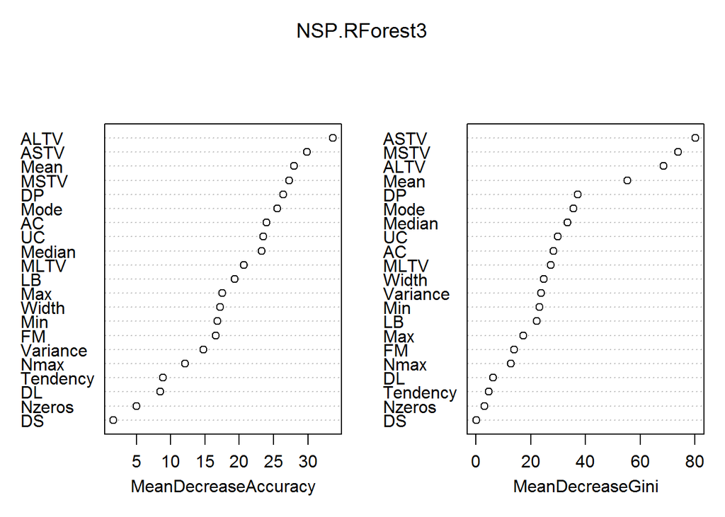

```r
varImpPlot(NSP.RForest3)
```

```r
#Validating

actual <- test1$NSP
NSP.RForest_predict<-predict(NSP.RForest3, test1 ,type="response")
NSP.RForest_results.matrix <- confusionMatrix(NSP.RForest_predict, actual,positive="yes")
print(NSP.RForest_results.matrix) #Accuracy 94.37, sensitivity class1-98.79, class2-75.0, class3-85.7 specificity: class1-84.21, class2-97.81, class3-99.74
```

```
## Confusion Matrix and Statistics
##
##           Reference
## Prediction   1   2   3
##          1 327  18   1
##          2   4  41   4
##          3   0   1  30
##
## Overall Statistics
##
##                Accuracy : 0.9343
##                  95% CI : (0.9064, 0.9559)
##     No Information Rate : 0.777
##     P-Value [Acc > NIR] : < 2.2e-16
##
##                   Kappa : 0.8104
##  Mcnemar's Test P-Value : 0.008449
##
## Statistics by Class:
##
##                      Class: 1 Class: 2 Class: 3
## Sensitivity            0.9879  0.68333  0.85714
## Specificity            0.8000  0.97814  0.99744
## Pos Pred Value         0.9451  0.83673  0.96774
## Neg Pred Value         0.9500  0.94960  0.98734
## Prevalence             0.7770  0.14085  0.08216
## Detection Rate         0.7676  0.09624  0.07042
## Detection Prevalence   0.8122  0.11502  0.07277
## Balanced Accuracy      0.8940  0.83074  0.92729
```

```r
print(NSP_results.matrix.bag)
```

```
## Confusion Matrix and Statistics
##
##           Reference
## Prediction   1   2   3
##          1 326  15   2
##          2   5  44   1
##          3   0   1  32
##
## Overall Statistics
##
##                Accuracy : 0.9437
##                  95% CI : (0.9173, 0.9636)
##     No Information Rate : 0.777
##     P-Value [Acc > NIR] : <2e-16
##
##                   Kappa : 0.8397
##  Mcnemar's Test P-Value : 0.0719
##
## Statistics by Class:
##
##                      Class: 1 Class: 2 Class: 3
## Sensitivity            0.9849   0.7333  0.91429
## Specificity            0.8211   0.9836  0.99744
## Pos Pred Value         0.9504   0.8800  0.96970
## Neg Pred Value         0.9398   0.9574  0.99237
## Prevalence             0.7770   0.1408  0.08216
## Detection Rate         0.7653   0.1033  0.07512
## Detection Prevalence   0.8052   0.1174  0.07746
## Balanced Accuracy      0.9030   0.8585  0.95586
```

Number of variables to be considered at each split = 5 Number of trees = 600

```r
NSP.RForest4 <- randomForest(NSP ~.,data=train1, mtry=5, ntree=600,na.action = na.omit, importance=TRUE)
print(NSP.RForest4) #OOB 5.82%
```

```
##
## Call:
##  randomForest(formula = NSP ~ ., data = train1, mtry = 5, ntree = 600,      importance = TRUE, na.action = na.omit)
##                Type of random forest: classification
##                      Number of trees: 600
## No. of variables tried at each split: 5
##
##         OOB estimate of  error rate: 5.41%
## Confusion matrix:
##      1   2   3 class.error
## 1 1302  17   5  0.01661631
## 2   53 178   4  0.24255319
## 3    6   7 128  0.09219858
```

```r
importance(NSP.RForest4)
```

```
##                   1          2          3 MeanDecreaseAccuracy
## LB       21.5672340 11.6157059 13.1603131            26.703557
## AC       26.5497718 22.1995214 16.9268953            30.709575
## FM       17.4694689 14.5282321  8.7559749            22.778591
## UC       20.5112061 22.5702734 22.7450681            31.697869
## DL        8.8691648  4.5210584  7.9533069            12.837921
## DS        0.9746561  0.0000000  1.0008344             2.006513
## DP       35.5747252 14.4682393 22.3348794            38.968904
## ASTV     27.4659186 41.0150769 37.5504345            46.019465
## MSTV     21.7978455 35.4361358 30.4079807            38.755625
## ALTV     30.3505750 30.7186469 33.4893519            43.031598
## MLTV     18.8304438 16.7728825 15.2373759            26.951742
## Width    16.3445714  6.4157554 13.6209160            21.711701
## Min      18.2934587 12.4602008 13.4084536            24.700420
## Max      16.4324257 11.4653844 11.3029860            22.975655
## Nmax     15.4525655  5.0518237  8.4863230            18.057982
## Nzeros    5.9533704  4.8024759 -0.1052407             7.415788
## Mode     24.3203476 13.9286259 16.9145139            31.305311
## Mean     29.0593518 18.0274690 29.0902715            39.228057
## Median   20.8017651 15.6906099 17.0776286            29.220145
## Variance 17.0741289  5.6527653 11.9152320            18.613796
## Tendency  9.7367681  0.8932646  7.1822470            11.377183
##          MeanDecreaseGini
## LB             20.7721563
## AC             29.2915697
## FM             13.5849241
## UC             28.9196804
## DL              5.1438091
## DS              0.1978027
## DP             35.9492867
## ASTV           88.1549850
## MSTV           84.6702941
## ALTV           71.5135250
## MLTV           26.8275189
## Width          20.2634094
## Min            22.4975780
## Max            15.7392114
## Nmax           11.7588113
## Nzeros          3.0030108
## Mode           32.2897318
## Mean           60.8710574
## Median         32.4893162
## Variance       16.8329173
## Tendency        3.9583843
```

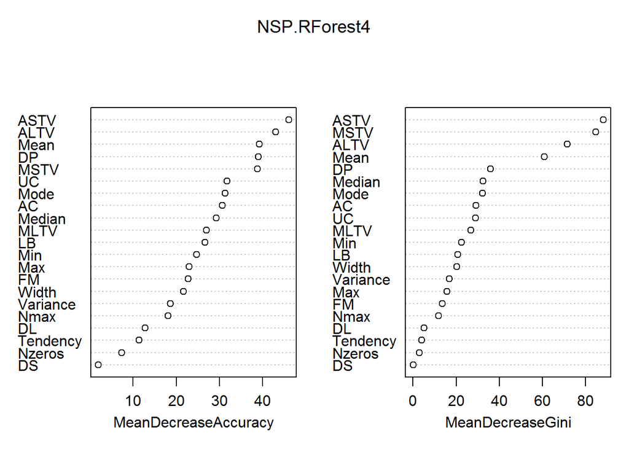

```r
varImpPlot(NSP.RForest4)
```

```r
#Validating

actual <- test1$NSP
NSP.RForest_predict<-predict(NSP.RForest4, test1 ,type="response")
NSP.RForest_results.matrix <- confusionMatrix(NSP.RForest_predict, actual,positive="yes")
print(NSP.RForest_results.matrix) #Accuracy 93.43, sensitivity class1-98.49, class2-70.0, class3-85.71 specificity: class1-80.0, class2-97.81, class3-99.74
```

```
## Confusion Matrix and Statistics
##
##           Reference
## Prediction   1   2   3
##          1 327  18   3
##          2   4  41   3
##          3   0   1  29
##
## Overall Statistics
##
##                Accuracy : 0.9319
##                  95% CI : (0.9037, 0.9539)
##     No Information Rate : 0.777
##     P-Value [Acc > NIR] : < 2.2e-16
##
##                   Kappa : 0.8019
##  Mcnemar's Test P-Value : 0.004837
##
## Statistics by Class:
##
##                      Class: 1 Class: 2 Class: 3
## Sensitivity            0.9879  0.68333  0.82857
## Specificity            0.7789  0.98087  0.99744
## Pos Pred Value         0.9397  0.85417  0.96667
## Neg Pred Value         0.9487  0.94974  0.98485
## Prevalence             0.7770  0.14085  0.08216
## Detection Rate         0.7676  0.09624  0.06808
## Detection Prevalence   0.8169  0.11268  0.07042
## Balanced Accuracy      0.8834  0.83210  0.91301
```

```r
print(NSP_results.matrix.bag)
```

```
## Confusion Matrix and Statistics
##
##           Reference
## Prediction   1   2   3
##          1 326  15   2
##          2   5  44   1
##          3   0   1  32
##
## Overall Statistics
##
##                Accuracy : 0.9437
##                  95% CI : (0.9173, 0.9636)
##     No Information Rate : 0.777
##     P-Value [Acc > NIR] : <2e-16
##
##                   Kappa : 0.8397
##  Mcnemar's Test P-Value : 0.0719
##
## Statistics by Class:
##
##                      Class: 1 Class: 2 Class: 3
## Sensitivity            0.9849   0.7333  0.91429
## Specificity            0.8211   0.9836  0.99744
## Pos Pred Value         0.9504   0.8800  0.96970
## Neg Pred Value         0.9398   0.9574  0.99237
## Prevalence             0.7770   0.1408  0.08216
## Detection Rate         0.7653   0.1033  0.07512
## Detection Prevalence   0.8052   0.1174  0.07746
## Balanced Accuracy      0.9030   0.8585  0.95586
```

Number of variables to be considered at each split = 3 Number of trees = 100

```r
NSP.RForest5 <- randomForest(NSP ~.,data=train1, mtry=3, ntree=100,na.action = na.omit, importance=TRUE)
print(NSP.RForest5) #OOB 6%
```

```
##
## Call:
##  randomForest(formula = NSP ~ ., data = train1, mtry = 3, ntree = 100,      importance = TRUE, na.action = na.omit)
##                Type of random forest: classification
##                      Number of trees: 100
## No. of variables tried at each split: 3
##
##         OOB estimate of  error rate: 6.06%
## Confusion matrix:
##      1   2   3 class.error
## 1 1297  22   5  0.02039275
## 2   51 179   5  0.23829787
## 3    8  12 121  0.14184397
```

```r
importance(NSP.RForest5)
```

```
##                  1          2         3 MeanDecreaseAccuracy
## LB        7.204449  6.5619711  6.621036            10.820480
## AC       10.390092  9.5664787  7.367536            12.501546
## FM        5.854454  7.7102183  5.522783            10.196452
## UC        9.451319  9.0070386  7.764283            12.512621
## DL        5.607799  1.9606521  4.351763             6.497170
## DS        1.650538  0.0000000  1.005038             1.916760
## DP       10.913624  5.9098972  8.725450            12.667878
## ASTV     11.830541 12.8777074 12.290453            16.205286
## MSTV      8.674221 12.3861799 11.523289            13.234319
## ALTV      9.713960 12.6933506 11.316770            15.621004
## MLTV      6.295878  8.1088347  6.183315            10.331319
## Width     7.694870  3.7309892  5.021501             8.778454
## Min       7.267035  5.1628374  5.490533             9.605956
## Max       7.176293  5.2692503  5.576882            10.097366
## Nmax      5.991364  0.8468915  4.176697             7.395843
## Nzeros    2.137173  3.0104835  3.035665             3.602431
## Mode      9.390291  5.1386760  7.525813            11.351871
## Mean     11.672727  7.3548642  9.680924            14.083589
## Median    9.525080  7.8134777  7.474690            14.125551
## Variance  8.322961  3.9467799  6.364159             9.796294
## Tendency  2.613832  3.9298843  2.428162             4.479535
##          MeanDecreaseGini
## LB             26.0862215
## AC             33.7266175
## FM             16.2905575
## UC             31.0741589
## DL              7.4119449
## DS              0.6176425
## DP             31.2903988
## ASTV           70.0632266
## MSTV           69.2335216
## ALTV           59.9495325
## MLTV           27.4750868
## Width          27.3590080
## Min            25.4000262
## Max            18.4193727
## Nmax           12.6429974
## Nzeros          3.9010087
## Mode           34.9819591
## Mean           56.9698142
## Median         39.6041148
## Variance       23.9378167
## Tendency        4.7170590
```

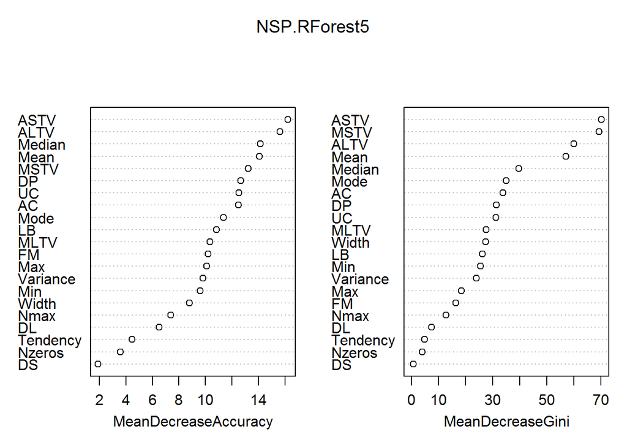

```r
varImpPlot(NSP.RForest5)
```

```r
#Validating

actual1 <- test1$NSP
NSP.RForest_predict1<-predict(NSP.RForest5, test1 ,type="response")
NSP.RForest_results.matrix1 <- confusionMatrix(NSP.RForest_predict1, actual1,positive="yes")
print(NSP.RForest_results.matrix1) #Accuracy 92.96, sensitivity: class1-98.49, class2-70.0, class3-80.0 specificity: class1-80.0, class2-97.26, class3-99.74
```

```
## Confusion Matrix and Statistics
##
##           Reference
## Prediction   1   2   3
##          1 328  17   2
##          2   3  42   5
##          3   0   1  28
##
## Overall Statistics
##
##                Accuracy : 0.9343
##                  95% CI : (0.9064, 0.9559)
##     No Information Rate : 0.777
##     P-Value [Acc > NIR] : < 2.2e-16
##
##                   Kappa : 0.8095
##  Mcnemar's Test P-Value : 0.002334
##
## Statistics by Class:
##
##                      Class: 1 Class: 2 Class: 3
## Sensitivity            0.9909  0.70000  0.80000
## Specificity            0.8000  0.97814  0.99744
## Pos Pred Value         0.9452  0.84000  0.96552
## Neg Pred Value         0.9620  0.95213  0.98237
## Prevalence             0.7770  0.14085  0.08216
## Detection Rate         0.7700  0.09859  0.06573
## Detection Prevalence   0.8146  0.11737  0.06808
## Balanced Accuracy      0.8955  0.83907  0.89872
```

```r
print(NSP_results.matrix.bag)
```

```
## Confusion Matrix and Statistics
##
##           Reference
## Prediction   1   2   3
##          1 326  15   2
##          2   5  44   1
##          3   0   1  32
##
## Overall Statistics
##
##                Accuracy : 0.9437
##                  95% CI : (0.9173, 0.9636)
##     No Information Rate : 0.777
##     P-Value [Acc > NIR] : <2e-16
##
##                   Kappa : 0.8397
##  Mcnemar's Test P-Value : 0.0719
##
## Statistics by Class:
##
##                      Class: 1 Class: 2 Class: 3
## Sensitivity            0.9849   0.7333  0.91429
## Specificity            0.8211   0.9836  0.99744
## Pos Pred Value         0.9504   0.8800  0.96970
## Neg Pred Value         0.9398   0.9574  0.99237
## Prevalence             0.7770   0.1408  0.08216
## Detection Rate         0.7653   0.1033  0.07512
## Detection Prevalence   0.8052   0.1174  0.07746
## Balanced Accuracy      0.9030   0.8585  0.95586
```

```r
print(NSP.RForest1)
```

```
##
## Call:
##  randomForest(formula = NSP ~ ., data = train1, mtry = 3, ntree = 400,      importance = TRUE, na.action = na.omit)
##                Type of random forest: classification
##                      Number of trees: 400
## No. of variables tried at each split: 3
##
##         OOB estimate of  error rate: 6.29%
## Confusion matrix:
##      1   2   3 class.error
## 1 1298  22   4  0.01963746
## 2   53 177   5  0.24680851
## 3    9  14 118  0.16312057
```

Number of variables to be considered at each split = 7 Number of trees = 400

```r
NSP.RForest6 <- randomForest(NSP ~.,data=train1, mtry=7, ntree=400,na.action = na.omit, importance=TRUE)
print(NSP.RForest6) #OOB 5.29
```

```
##
## Call:
##  randomForest(formula = NSP ~ ., data = train1, mtry = 7, ntree = 400,      importance = TRUE, na.action = na.omit)
##                Type of random forest: classification
##                      Number of trees: 400
## No. of variables tried at each split: 7
##
##         OOB estimate of  error rate: 5.71%
## Confusion matrix:
##      1   2   3 class.error
## 1 1295  22   7  0.02190332
## 2   51 180   4  0.23404255
## 3    6   7 128  0.09219858
```

```r
importance(NSP.RForest6)
```

```
##                  1         2          3 MeanDecreaseAccuracy
## LB       16.410398  8.381089  9.6158940            20.315839
## AC       23.446417 17.245451 11.9222458            26.255124
## FM       13.623369 12.755666  5.2995406            18.166590
## UC       16.698472 19.063924 19.8391322            27.186772
## DL        8.029053  3.136522  5.4282639             9.760358
## DS        1.972596  1.001252  1.0012523             2.422652
## DP       34.338427 11.094563 17.5978966            36.748457
## ASTV     21.713934 38.229270 35.8043391            41.099634
## MSTV     18.354612 32.984541 28.5595971            35.996938
## ALTV     29.477891 30.250915 31.3241456            43.952501
## MLTV     15.691959 12.646647 11.8162674            21.348431
## Width    12.504501  7.062311  9.1459602            16.955347
## Min      14.304500  9.758340  8.8943978            18.069490
## Max      12.817829  7.928930  7.5760035            17.124540
## Nmax     11.195088  4.330807  6.3695388            13.538866
## Nzeros    6.180419  4.268136  0.7451927             7.488276
## Mode     20.128914 10.614972 12.4810908            25.569495
## Mean     25.963489 14.211653 25.4768007            33.299867
## Median   17.534774 10.697956 13.8720587            24.447729
## Variance 13.334186  2.657391  7.1054195            13.378308
## Tendency  5.446805  0.524943  4.4294764             6.459167
##          MeanDecreaseGini
## LB             17.8746071
## AC             25.7444505
## FM             11.6185638
## UC             26.0981775
## DL              4.6470079
## DS              0.2295849
## DP             39.3621982
## ASTV           96.3415851
## MSTV           92.9708529
## ALTV           78.5112696
## MLTV           24.7005252
## Width          19.3596206
## Min            18.4090967
## Max            14.1331055
## Nmax           11.5222331
## Nzeros          3.0563408
## Mode           27.7476568
## Mean           63.8151356
## Median         29.3013504
## Variance       12.8770560
## Tendency        3.5272584
```

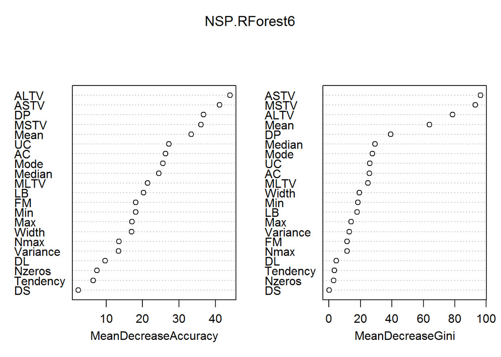

```r
varImpPlot(NSP.RForest6)
```

```r
#Validating

actual2 <- test1$NSP
NSP.RForest_predict2<-predict(NSP.RForest6, test1 ,type="response")
NSP.RForest_results.matrix2 <- confusionMatrix(NSP.RForest_predict2, actual2,positive="yes")
print(NSP.RForest_results.matrix2) #Accuracy: 94.37, sensitivity: class1-98.49, cl2ass 2-73.33, class3-91.42 specificity: class1-82.11, class2-98.36,class3-99.74
```

```
## Confusion Matrix and Statistics
##
##           Reference
## Prediction   1   2   3
##          1 325  15   3
##          2   6  44   2
##          3   0   1  30
##
## Overall Statistics
##
##                Accuracy : 0.9366
##                  95% CI : (0.9091, 0.9578)
##     No Information Rate : 0.777
##     P-Value [Acc > NIR] : < 2e-16
##
##                   Kappa : 0.8195
##  Mcnemar's Test P-Value : 0.06607
##
## Statistics by Class:
##
##                      Class: 1 Class: 2 Class: 3
## Sensitivity            0.9819   0.7333  0.85714
## Specificity            0.8105   0.9781  0.99744
## Pos Pred Value         0.9475   0.8462  0.96774
## Neg Pred Value         0.9277   0.9572  0.98734
## Prevalence             0.7770   0.1408  0.08216
## Detection Rate         0.7629   0.1033  0.07042
## Detection Prevalence   0.8052   0.1221  0.07277
## Balanced Accuracy      0.8962   0.8557  0.92729
```

```r
print(NSP_results.matrix.bag)
```

```
## Confusion Matrix and Statistics
##
##           Reference
## Prediction   1   2   3
##          1 326  15   2
##          2   5  44   1
##          3   0   1  32
##
## Overall Statistics
##
##                Accuracy : 0.9437
##                  95% CI : (0.9173, 0.9636)
##     No Information Rate : 0.777
##     P-Value [Acc > NIR] : <2e-16
##
##                   Kappa : 0.8397
##  Mcnemar's Test P-Value : 0.0719
##
## Statistics by Class:
##
##                      Class: 1 Class: 2 Class: 3
## Sensitivity            0.9849   0.7333  0.91429
## Specificity            0.8211   0.9836  0.99744
## Pos Pred Value         0.9504   0.8800  0.96970
## Neg Pred Value         0.9398   0.9574  0.99237
## Prevalence             0.7770   0.1408  0.08216
## Detection Rate         0.7653   0.1033  0.07512
## Detection Prevalence   0.8052   0.1174  0.07746
## Balanced Accuracy      0.9030   0.8585  0.95586
```

Number of variables to be considered at each split = 7 Number of trees = 550

```r
NSP.RForest7 <- randomForest(NSP ~.,data=train1, mtry=7, ntree=550,na.action = na.omit, importance=TRUE)
print(NSP.RForest7) #OOB 5.29
```

```
##
## Call:
##  randomForest(formula = NSP ~ ., data = train1, mtry = 7, ntree = 550,      importance = TRUE, na.action = na.omit)
##                Type of random forest: classification
##                      Number of trees: 550
## No. of variables tried at each split: 7
##
##         OOB estimate of  error rate: 5.65%
## Confusion matrix:
##      1   2   3 class.error
## 1 1295  21   8  0.02190332
## 2   50 181   4  0.22978723
## 3    6   7 128  0.09219858
```

```r
importance(NSP.RForest7)
```

```
##                  1          2          3 MeanDecreaseAccuracy
## LB       19.942183 11.3307418 11.7068023            24.105991
## AC       26.549660 20.4151673 13.6355886            31.591333
## FM       14.544673 13.3074963  7.0395622            20.099966
## UC       20.825984 21.6894735 22.8128708            32.795664
## DL        6.927897  2.6874073  7.1040084            10.291864
## DS        1.896154  0.0000000  1.3666969             1.801308
## DP       38.204529 15.4879636 22.3300970            43.469219
## ASTV     25.509986 44.7457439 42.5604844            50.849013
## MSTV     22.413152 38.1808243 33.6177533            42.417962
## ALTV     34.849457 34.0727579 38.2786522            50.428862
## MLTV     18.904191 16.3461971 14.7352834            25.554528
## Width    15.319790  5.5419616 11.1704798            20.628231
## Min      17.235710 10.5360017 10.6710583            22.310785
## Max      14.721117  8.0790031  9.0767859            19.426279
## Nmax     14.637326  5.6383709  6.6893017            16.634281
## Nzeros    6.585011  3.4910063 -0.3212467             7.504055
## Mode     23.789020 12.1667598 15.3548076            30.536747
## Mean     31.115668 15.5692016 28.9904824            40.342104
## Median   18.874322 11.5802634 14.1137824            25.728475
## Variance 15.316993  3.4488155  9.2459247            16.002634
## Tendency  7.794157  0.7220791  5.9342682             9.638903
##          MeanDecreaseGini
## LB             18.2583275
## AC             24.9574940
## FM             11.8597818
## UC             25.2558733
## DL              4.0980489
## DS              0.1807794
## DP             41.3320904
## ASTV           97.5626043
## MSTV           92.5493503
## ALTV           81.3036738
## MLTV           24.9447746
## Width          17.5298422
## Min            18.9810189
## Max            13.7066381
## Nmax           11.7034844
## Nzeros          3.4397278
## Mode           29.9141447
## Mean           63.8873134
## Median         27.1274390
## Variance       13.1958234
## Tendency        3.6674045
```

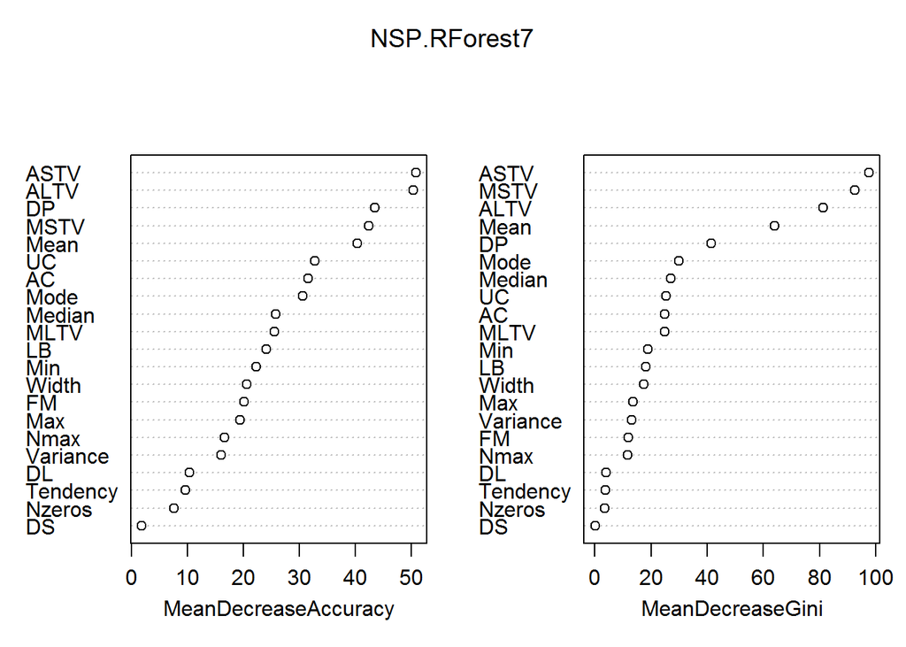

```r
varImpPlot(NSP.RForest7)
```

```r
#Validating

actual2 <- test1$NSP
NSP.RForest_predict2<-predict(NSP.RForest7, test1 ,type="response")
NSP.RForest_results.matrix2 <- confusionMatrix(NSP.RForest_predict2, actual2,positive="yes")
print(NSP.RForest_results.matrix2) #Accuracy 93.66, sensitivity class1-98.19 class2-73.33 class3-85.7 specificity class1 81.05 class2-97.81 class3 99.74
```

```
## Confusion Matrix and Statistics
##
##           Reference
## Prediction   1   2   3
##          1 325  15   3
##          2   6  44   2
##          3   0   1  30
##
## Overall Statistics
##
##                Accuracy : 0.9366
##                  95% CI : (0.9091, 0.9578)
##     No Information Rate : 0.777
##     P-Value [Acc > NIR] : < 2e-16
##
##                   Kappa : 0.8195
##  Mcnemar's Test P-Value : 0.06607
##
## Statistics by Class:
##
##                      Class: 1 Class: 2 Class: 3
## Sensitivity            0.9819   0.7333  0.85714
## Specificity            0.8105   0.9781  0.99744
## Pos Pred Value         0.9475   0.8462  0.96774
## Neg Pred Value         0.9277   0.9572  0.98734
## Prevalence             0.7770   0.1408  0.08216
## Detection Rate         0.7629   0.1033  0.07042
## Detection Prevalence   0.8052   0.1221  0.07277
## Balanced Accuracy      0.8962   0.8557  0.92729
```

```r
print(NSP_results.matrix.bag)
```

```
## Confusion Matrix and Statistics
##
##           Reference
## Prediction   1   2   3
##          1 326  15   2
##          2   5  44   1
##          3   0   1  32
##
## Overall Statistics
##
##                Accuracy : 0.9437
##                  95% CI : (0.9173, 0.9636)
##     No Information Rate : 0.777
##     P-Value [Acc > NIR] : <2e-16
##
##                   Kappa : 0.8397
##  Mcnemar's Test P-Value : 0.0719
##
## Statistics by Class:
##
##                      Class: 1 Class: 2 Class: 3
## Sensitivity            0.9849   0.7333  0.91429
## Specificity            0.8211   0.9836  0.99744
## Pos Pred Value         0.9504   0.8800  0.96970
## Neg Pred Value         0.9398   0.9574  0.99237
## Prevalence             0.7770   0.1408  0.08216
## Detection Rate         0.7653   0.1033  0.07512
## Detection Prevalence   0.8052   0.1174  0.07746
## Balanced Accuracy      0.9030   0.8585  0.95586
```

Peer- “Great presentation.Possibly try a boosting model to see if sensitivity will be lower than bagging model”

Peer recommended Boosting Model:

Boosting Model- I have pruned the decision tree using recommended cp-value, however It did not Improve the Accuracy of the model and Sensitivity of target variable further went down.

```r
set.seed(123)
cvCtrl <- trainControl(method="boot", number=10)
NSP.boost<-train(NSP ~., data=train1, method="rpart", metric="Accuracy", tuneLength=10, trControl=cvCtrl)
NSP.boost
```

```
## CART
##
## 1700 samples
##   21 predictor
##    3 classes: '1', '2', '3'
##
## No pre-processing
## Resampling: Bootstrapped (10 reps)
## Summary of sample sizes: 1700, 1700, 1700, 1700, 1700, 1700, ...
## Resampling results across tuning parameters:
##
##   cp           Accuracy   Kappa
##   0.000000000  0.9067276  0.7450284
##   0.005319149  0.9089954  0.7522605
##   0.007978723  0.9099556  0.7524519
##   0.009751773  0.9118112  0.7569629
##   0.011524823  0.9105685  0.7512089
##   0.037234043  0.9026749  0.7205949
##   0.050531915  0.8928344  0.6934624
##   0.086436170  0.8728697  0.6427371
##   0.180851064  0.8153561  0.3321330
##   0.210106383  0.7854257  0.1375768
##
## Accuracy was used to select the optimal model using  the largest value.
## The final value used for the model was cp = 0.009751773.
```

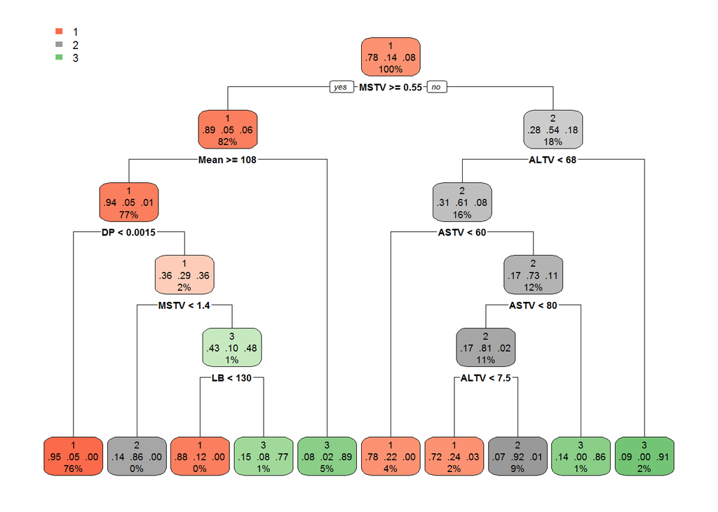

```r
NSP.rpart.pruned.boot<-prune(NSP.rpart1, cp=0.009751773)
rpart.plot(NSP.rpart.pruned.boot)
```

```r
# validating.

actual <- test1$NSP
NSP_predicted.boot <- predict(NSP.rpart.pruned.boot, newdata= test1, type="class")
NSP_results.matrix.boot <- confusionMatrix(NSP_predicted.boot, actual, positive="yes")
print(NSP_results.matrix.boot)
```

```
## Confusion Matrix and Statistics
##
##           Reference
## Prediction   1   2   3
##          1 321  29   1
##          2   4  31   1
##          3   6   0  33
##
## Overall Statistics
##
##                Accuracy : 0.9038
##                  95% CI : (0.8717, 0.93)
##     No Information Rate : 0.777
##     P-Value [Acc > NIR] : 5.087e-12
##
##                   Kappa : 0.7172
##  Mcnemar's Test P-Value : 3.160e-05
##
## Statistics by Class:
##
##                      Class: 1 Class: 2 Class: 3
## Sensitivity            0.9698  0.51667  0.94286
## Specificity            0.6842  0.98634  0.98465
## Pos Pred Value         0.9145  0.86111  0.84615
## Neg Pred Value         0.8667  0.92564  0.99483
## Prevalence             0.7770  0.14085  0.08216
## Detection Rate         0.7535  0.07277  0.07746
## Detection Prevalence   0.8239  0.08451  0.09155
## Balanced Accuracy      0.8270  0.75150  0.96376
```

```r
# Accuracy of 90.38, Sensitivity of class 1-96.98, Class 2-51.6, class 3-94.28 and Specificty of Class 1-68.42, Class 2-98.63 and Class 3-98.46.
```

Preferred Model: Bagging Model is my preferred model as it has high Accuracy and high Sensitivity in Class 2(Suspect) and class3(Pathologic) levels of my target variable.

Recommendations: -The correct determination of state of fetus is especially important for early intervention of required cases, i.e. fetal distress or preventing unnecessary surgeries. -Most people are often prone to make mistakes during analysis or, possibly, when trying to establish relationships between multiple features. This makes it difficult for them to find solutions to certain problems.The discussed models can be successfully applied to these problems. -These models can also aid in improving the efficiency of systems and the designs of machines. -Variables such as - Percentage of time with abnormally short and abnormally long term Variability (ASTV and ALTV), Uterine contractions (UC) are Important and Doctors need to be more careful when looking at their readings.